# Sample Means of an Exponential Function

Sample Means of an Exponential Function Project by Vanshaj S.

## Introduction

In this “study,” we’re going to take a look at a sample of exponential distributions and compare its mean and variance to the expected mean and variance, mathematically calculated.

## Required Libraries

For ease (and beauty) of graphing, let’s use the ggplot2 library.

```r
library(ggplot2)
```

## Setup

To ensure reproducibility, let’s set a random seed. We’ll also define our variables for future use.

```r
set.seed(8243)            # reproducibility

lambda <- 0.2             # as instructed
sample.size <- 40         # as instructed
sample.num <- 1000        # as instructed

binwidth <- 0.1           # a near-perfect binwidth :)
steelblue <- "steelblue"  # a great fill color
orange <- "#c56000"       # a great line color
```

## Accumulation

Let’s begin by accumulating our samples. For this project, we take 1,000 samples of size 40 from an exponential distribution.

```r
exp.mns <- NULL
for (i in 1 : sample.num) exp.mns = c(exp.mns, mean(rexp(sample.size, lambda)))
```

## Display

Firstly, we’ll make a histogram of our sample means with a relevant normal density curve superimposed to show the decent normality of our data.

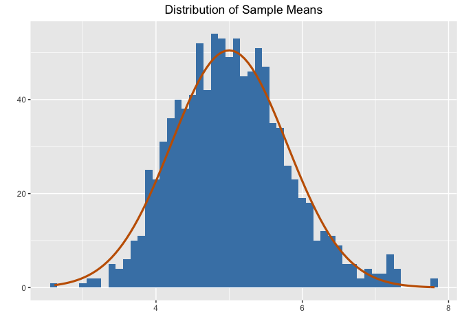

```r
qplot(exp.mns, geom="histogram", binwidth = binwidth, fill = I(steelblue)) +
  stat_function(
    fun = function(x, mean, sd, n, bin){
      dnorm(x = x, mean = mean, sd = sd) * n * bin
    },
    args = c(mean = 1/lambda, sd = (1/lambda)/sqrt(sample.size),
             n = sample.num, bin = binwidth), col = I(orange), size = 1.1) +
  labs(title = "Distribution of Sample Means", x = "") +
  theme(plot.title = element_text(hjust = 0.5))
```

## Comparisons

Let’s take a look at the theoretical versus the sample means.

```r
## Theoretical Mean
1/lambda

## Experimental Mean
mean(exp.mns)
```

Running this code gives us a theoretical mean of 5 and an experimental mean of 5.0365308. Pretty close.

Let’s look at the variances as well.

```r
## Theoretical Variance
((1/lambda)^2)/sample.size

## Experimental Variance
var(exp.mns)
```

Running this code gives us a theoretical variance of 0.625 and an experimental variance of 0.600561. Again, pretty close.

## Check for Normality

If you weren’t hold from the histogram, let’s make a normal quantile plot of the data. Essentially, the normal quantile plot’s linearity is what proves the normality of the data – the more linear the plot, the more normal the data.

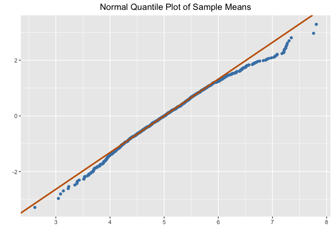

```r
x <- qnorm(c(0.25, 0.75))
y <- quantile(exp.mns, c(0.25, 0.75))

slope <- diff(y)/diff(x)
int <- y[1L] - (slope * x[1L])

d <- data.frame(exp.mns)

ggplot(d, aes(sample = exp.mns, col = I(steelblue))) + geom_qq() +
  geom_abline(slope = slope, intercept = int, col = I(orange), size = 1.1) +
  labs(title = "Normal Quantile Plot of Sample Means", x = "", y = "") +
  theme(plot.title = element_text(hjust = 0.5)) + coord_flip()
```